# Network-Based Connectivity Data Simulation

Eric Reed

12/22/2020

# Requirements

## R Packages and Python Modules

```r
## R packages to run simulation functions
require(magrittr)
library(igraph)
library(reticulate)
library(Matrix)
library(BDgraph)
library(ggplot2)
require(corpcor)
require(MASS)

## R packages for visualization
require(ggplot2)
require(gridExtra)

## Python modules
nx <- import("networkx")
```

## Directories

```r
baseDir <- ".." # If running from the "./docs" directory
rDir <- file.path(baseDir, "R")
pyDir <- file.path(baseDir, "python")
```

## Read in functions

```r
## Read in R functions
rDir %>%
    list.files(., full.names = TRUE) %>%
    lapply(., source) %>%
    invisible # This keeps lapply from printing NULL

## Read in python functions
source_python(file.path(pyDir, "LFR_Communities.py"))
```

# Simulating scale-free networks and adjacency matrices

## Simulating scale-free networks

The `simNetComs()` function simulates a set of communities and builds a scale-free based on this community structure using python functions which can be found in **LFR_Comminities.py**. **LFR_Comminities.py** includes functions from the *networkx* python library for creating scale-free networks according to specified paramaters. For more information about paramerization go [here](https://networkx.org/documentation/stable/reference/generated/networkx.generators.community.LFR_benchmark_graph.html).

`simNetComs()` returns a named list of two elements:

1. `ig`: an *igraph* object containing the network.
2. `coms`: a factor vector containing the community assignment for each node.

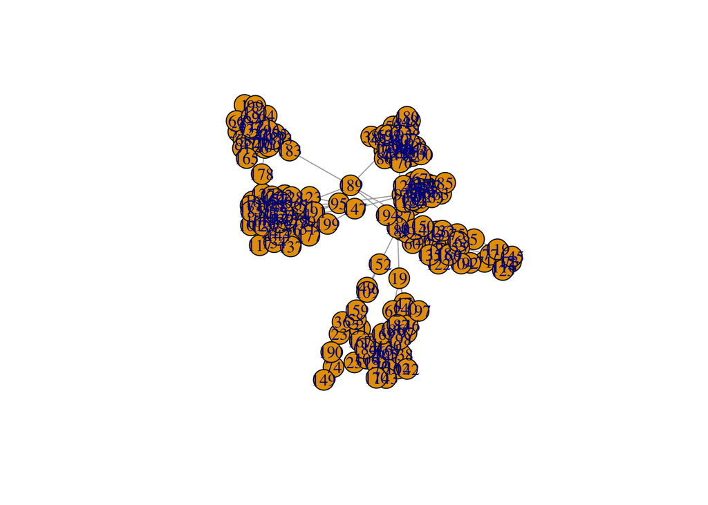

```r
netComs <- simNetComs(seed=12345,
                      n=200,
                      tau1=3,
                      tau2=2,
                      mu=0.07,
                      average_degree=5,
                      min_community=25,
                      max_community=50)

## Plot graph
plot(netComs$ig)
```

```r
## Print table of community sizes
print(table(netComs$coms))
```

```
##
##  1  2  3  4  5  6
## 26 33 25 45 40 31
```

## Simulating adjacency matrices

The `simAdjMat()` function performs two main tasks:

1. Simulates a correlation matrix from the *igraph* element of the output of `simNetComs()`.
   - Uses functionality adapted from `BDgraph::bdgraph.sim()`.
2. Calculates community and background connectivities from this correlation matrix.

**Important: The simulation of the correlation matrix is a stochastic process. The simulated correlation matricies will be completely different if repeated if no or different seeds are specified, even though the input networks are the same.**

`simAdjMat()` returns a named list of 5 elements:

1. adjMat: Simulated correlation matrix.
2. conns: Named numeric vector of community connectivies.
3. bg: Background connectivity.
4. coms: Factor vector containing the community assignment for each node (Same as netComs$coms).
5. adjNet: Sparse matrix of converted from original graph input, i.e. 0’s and 1’s.

```r
set.seed(123)
netConn <- simAdjMat(netComs)

## Print dimension of correlation matrix
print(dim(netConn$adjMat))
```

```
## [1] 200 200
```

```r
## Print community connectivities
print(netConn$conns)
```

```
##       1.1       2.2       3.3       4.4       5.5       6.6
## 0.2915914 0.2548466 0.5260009 0.2970020 0.1173710 0.4085283
```

```r
## Print background connectivities
print(netConn$bg)
```

```
## [1] 0.09364391
```

```r
## Print table of community sizes (Same as netComs)
print(table(netConn$coms))
```

```
##
##  1  2  3  4  5  6
## 26 33 25 45 40 31
```

```r
## Print dimension of sparse network adjacencies
dim(netConn$adjNet)
```

```
## [1] 200 200
```

### Visualize simulated adjacencies

The `simAdj2df()` creates a data frame from the output of `simAdjMat()` containing the upper triangle of relavant adjacencies for visualization. This data from contains 3 columns

- cors = Upper triangle of correlation matrix.
- edges = Upper triangle of adjacency matrix of original graph.
- coms = Upper triangle of matrix defining community connections (“0” if not in the same community).

```r
adjDF <- simAdj2df(netConn)

## Print first 6 rows
head(adjDF)
```

```
##         cors edges coms
## 1 0.31467164     0    0
## 2 0.43808998     0    1
## 3 0.61401375     0    0
## 4 0.09307487     0    0
## 5 0.17595458     0    0
## 6 0.18359749     0    0
```

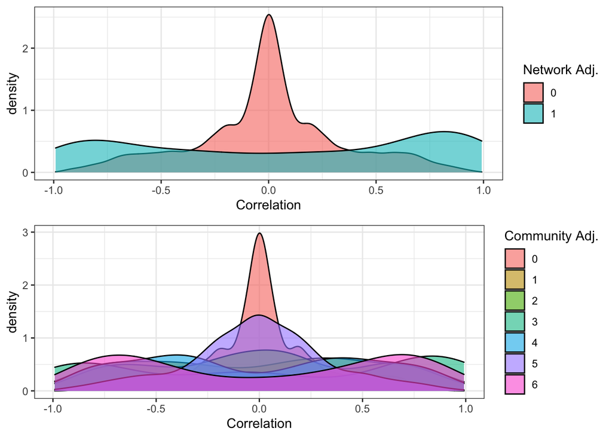

```r
## Visualize results

### Correlation and edge adjacency
ceDens <- ggplot(data = adjDF, aes(x = cors, group = edges, fill = as.factor(edges))) +
    geom_density(alpha = 0.6) +
    scale_fill_discrete(name = "Network Adj.") +
    scale_x_continuous(name = "Correlation") +
    theme_bw()

### Correlation and community adjacency
ccDens <- ggplot(data = adjDF, aes(x = cors, group = coms, fill = coms)) +
    geom_density(alpha = 0.6) +
    scale_fill_discrete(name = "Community Adj.") +
    scale_x_continuous(name = "Correlation") +
    theme_bw()

grid.arrange(ceDens, ccDens, ncol = 1)
```

### Run `simAdjMat()` again and compare to original

```r
set.seed(124) # Different seed
netConnNew <- simAdjMat(netComs)

## Community connectivities are different are different

### Original
print(netConn$conns)
```

```
##       1.1       2.2       3.3       4.4       5.5       6.6
## 0.2915914 0.2548466 0.5260009 0.2970020 0.1173710 0.4085283
```

```r
### New
print(netConnNew$conns)
```

```
##        1.1        2.2        3.3        4.4        5.5        6.6
## 0.16990380 0.11275870 0.12007780 0.09672827 0.11387816 0.08827138
```

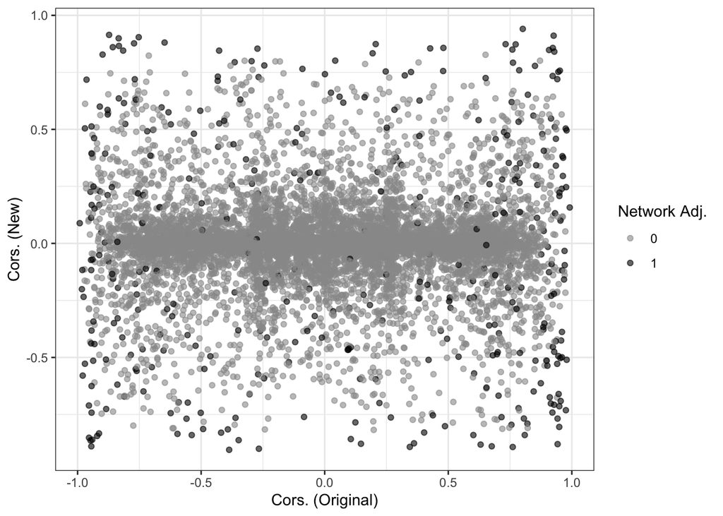

```r
## Plot correlations between runs

# Add new correlations to adjDF
adjDF$rep <- simAdj2df(netConnNew)$cors

# Compare and plot edge adjacency
ggplot(data = adjDF, aes(x = cors, y = rep, color = as.factor(edges))) +
    geom_point(alpha = 0.6) +
    scale_x_continuous("Cors. (Original)") +
    scale_y_continuous("Cors. (New)") +
    scale_color_manual(name = "Network Adj.", values = c("1" = "black", "0" = "grey60")) +
    theme_bw()
```

# Simulating data from correlation matrices

The `BDgraph::bdgraph.sim()` function generates data using the same `mvrnorm()` function from the **MASS** package. Accordingly, the `simAdj2data()` is wrapper for `mvrnorm()`, which uses the output of `simAdjMat()` to generate an *n by p* matrix of multivariate normal data.

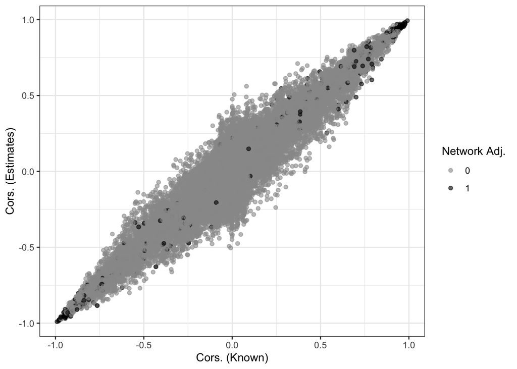

```r
simDat <- simAdj2data(netConn, 50)

## Compare estimated correlations to known correlations
simCors <- cor(simDat)
adjDF$sims <- simCors[upper.tri(simCors)]

# Compare and plot adjacency
ggplot(data = adjDF, aes(x = cors, y = sims, color = as.factor(edges))) +
    geom_point(alpha = 0.6) +
    scale_x_continuous("Cors. (Known)") +
    scale_y_continuous("Cors. (Estimates)") +
    scale_color_manual(name = "Network Adj.", values = c("1" = "black", "0" = "grey60")) +
    theme_bw()
```

# Controlling the distribution of simulated correlations

```r
## Create D matrix
Dmat <- matrix(0.50, ncol = length(netComs$coms), nrow = length(netComs$coms))
diag(Dmat) <- 1

## Use D matrix in correlation estimates
set.seed(123)
netConnD50 <- simAdjMat(netComs, D = Dmat)

## Print community connectivities
print(netConn$conns)
```

```
##       1.1       2.2       3.3       4.4       5.5       6.6
## 0.2915914 0.2548466 0.5260009 0.2970020 0.1173710 0.4085283
```

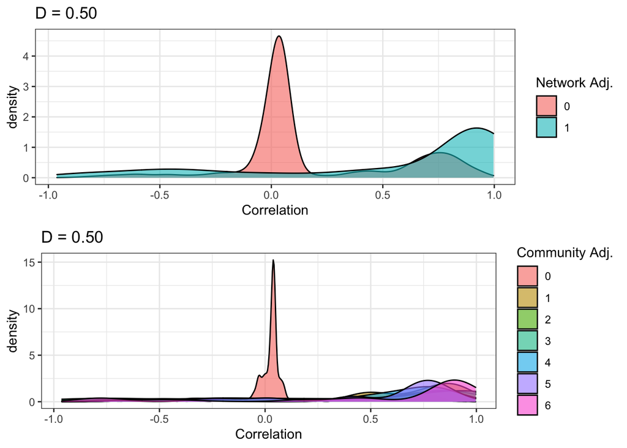

```r
## Visualize distribution
adjDF50 <- simAdj2df(netConnD50)

## Visualize results

### Correlation and edge adjacency
ceDens50 <- ggplot(data = adjDF50, aes(x = cors, group = edges, fill = as.factor(edges))) +
    geom_density(alpha = 0.6) +
    scale_fill_discrete(name = "Network Adj.") +
    scale_x_continuous(name = "Correlation") +
    theme_bw() +
    ggtitle("D = 0.50")

### Correlation and community adjacency
ccDens50 <- ggplot(data = adjDF50, aes(x = cors, group = coms, fill = coms)) +
    geom_density(alpha = 0.6) +
    scale_fill_discrete(name = "Community Adj.") +
    scale_x_continuous(name = "Correlation") +
    theme_bw() +
    ggtitle("D = 0.50")

grid.arrange(ceDens50, ccDens50, ncol = 1)
```

# Simulating differential connectivity

## Manually reducing connectivity of simulated correlation matrix

Once we estimate the correlation matrix, we can reduce the connectivity by shrinking the magnitude of correlation values, while preserving positive definiteness, using **arctan** transformations of the correlation values. The **arctan** of correlation is normally distributed.

This is done in three steps:

1. Transform correlation matrix with the `arctan()` function.
2. Multiply by a *“shrinking factor”* between 0 and 1.
3. Transform values back into correlations using the `tan()` function.

```r
## Get correlation matrix
corD50 <- netConnD50$adjMat

## It's positive definite
is.positive.definite(corD50)
```

```
## [1] TRUE
```

```r
## Shrink by a factor of 0.50
corD50red <- tanh(atanh(corD50) * 0.5)

## It's also positive definite
is.positive.definite(corD50red)
```

```
## [1] TRUE
```

```r
## Connectivities of original correlation matrix
netConnD50$conns
```

```
##       1.1       2.2       3.3       4.4       5.5       6.6
## 0.5203197 0.4529601 0.6999465 0.4082729 0.4384006 0.6247427
```

```r
## Connectivities of new correlation matrix
getComConn(levels(netConnD50$coms), corD50red, netConnD50$coms)
```

```
##         1         2         3         4         5         6
## 0.2269092 0.1962444 0.3786580 0.1573968 0.1715181 0.2956555
```

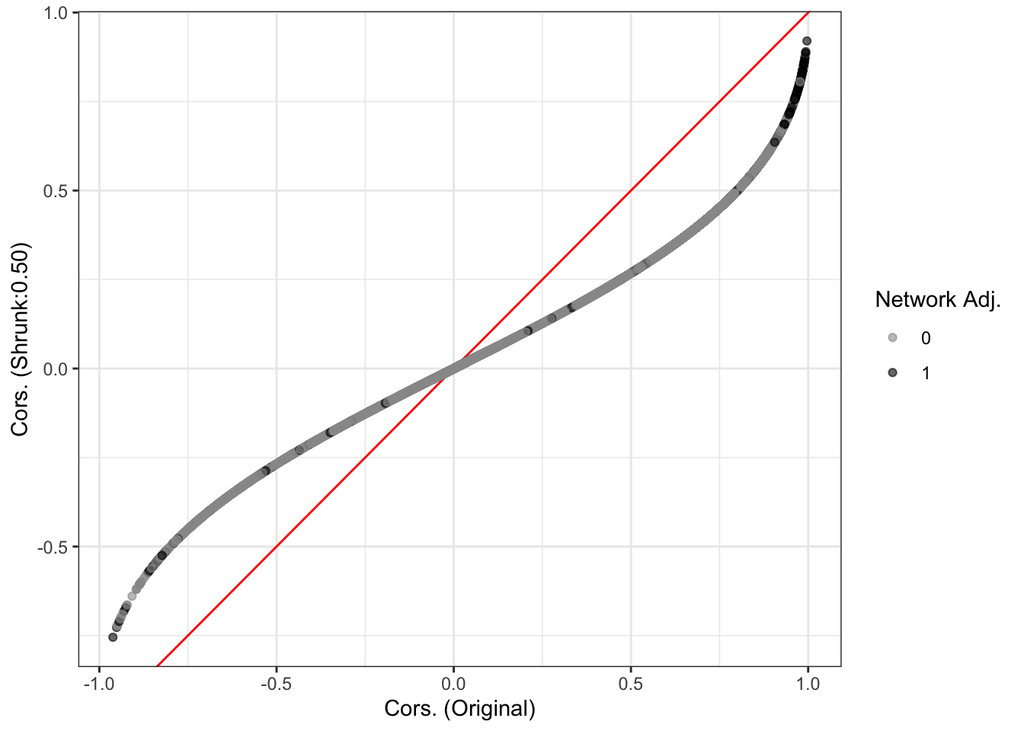

```r
## Compare the distributions of connectivities

### Add reduced correlations to adjDF50
adjDF50$red <- corD50red[upper.tri(corD50red)]

ggplot(data = adjDF50, aes(x = cors, y = red, color = as.factor(edges))) +
    geom_abline(intercept = 0, slope = 1, color = "red") +
    geom_point(alpha = 0.6) +
    scale_x_continuous("Cors. (Original)") +
    scale_y_continuous("Cors. (Shrunk:0.50)") +
    scale_color_manual(name = "Network Adj.", values = c("1" = "black", "0" = "grey60")) +
    theme_bw()
```

This transformation doesn’t work in the other direction, at least in that it does not preserve positive definateness of the correlation matrix.

```r
## Increase by a factor of 1.1
corD50inc <- tanh(atanh(corD50) * 1.1)

## It's not positive definite
is.positive.definite(corD50inc)
```

```
## [1] FALSE
```

## Reducing connectivity to a specified value

In the example above we used a *shrinking factor* of 0.5, which reduced the connectivity of community:1 from 0.52 to 0.23. Suppose we wanted to shrink the connectivity to only 0.50 to have a nice round number for simulation. Then, suppose we have want to simulate the power to detect differential connectivity in another group with connectivity of 0.40. We can do this, however there’s no close form (I wasn’t able to find a) solution for calculating what these shrinking factors should be.

The function `findShrinkFactor()` searches for the optimal shrinking value, using a target connectivity and the original adjacency matrix and returns the appropriate shrinking factor.

Below we estimate the shrinking factor to reduce the connectivity of community:1 to 0.5. Since we are only interested in shrinking community:1, we will need to subset the correlation matrix.

```r
# Subset correlation matrix
corD50_com1 <- corD50[netConnD50$coms == "1", netConnD50$coms == "1"]

# Finding shrinking factor to reduce connectivity to 0.50
sf <- findShrinkFactor(0.5, corD50_com1)

# What is it?
sf
```

```
## [1] 0.9573028
```

Now if we shrink the entire correlation matrix by this factor, the connectivity of community:1 will be very close to 0.50. Will will use the `shrinkCor()` function to shrinking correlation matrices, which is just a wrapper for the shrinking transformation.

```r
# Reduce correlations by shrinking factor
corD50targ <- shrinkCor(corD50, sf)

## Original connectivities
netConnD50$conns
```

```
##       1.1       2.2       3.3       4.4       5.5       6.6
## 0.5203197 0.4529601 0.6999465 0.4082729 0.4384006 0.6247427
```

```r
## Connectivities of new correlation matrix
getComConn(levels(netConnD50$coms), corD50targ, netConnD50$coms)
```

```
##         1         2         3         4         5         6
## 0.5000067 0.4354177 0.6823199 0.3890237 0.4185226 0.6048146
```

Alternatively, we can reduce only the nodes in community:1 and replace these values in the original correlation matrix. This will still preserve the positive definitness of the correlation matrix.

```r
## Reduce only correlations in community:1
corD50_com1targ <- shrinkCor(corD50_com1, sf)

## Replace is back into the original correlation matrix
corD50_com1rep <- corD50
corD50_com1rep[netConnD50$coms == "1", netConnD50$coms == "1"] <- corD50_com1targ

## It's still positive definite
is.positive.definite(corD50_com1rep)
```

```
## [1] TRUE
```

```r
## Original connectivities
netConnD50$conns
```

```
##       1.1       2.2       3.3       4.4       5.5       6.6
## 0.5203197 0.4529601 0.6999465 0.4082729 0.4384006 0.6247427
```

```r
## Connectivities of new correlation matrix
getComConn(levels(netConnD50$coms), corD50_com1rep, netConnD50$coms)
```

```
##         1         2         3         4         5         6
## 0.5000067 0.4529601 0.6999465 0.4082729 0.4384006 0.6247427
```